# Comp Meth

## Downloading and cleaning the Data

Predicting the housing prices in household surveys in Uganda

```r
# Load the necessary libraries
library(tidyverse)

# Load the data into R (replace "data.csv" with the actual filename and path of your data)
data <- read_csv("data.csv")
```

```r
install.packages("gbm")
```

```r
head(data)
```

| household_id | housing_price | Rent | timeunit_rent | area_property | area_property_unit | cooking_fuel | electricity | electricity_ESCOM | electricity_cost_period | MTLtelephone | source_drinkingWater | toilet_facility | disposal_facility | use_bednet |
| --- | --- | --- | --- | --- | --- | --- | --- | --- | --- | --- | --- | --- | --- | --- |
| c58e3284fee84a598b22086985e8212a | 30000 | 5000 | 5 | NA | NA | 1 | 2 | NA | NA | 2 | 7 | 5 | 6 | 2 |
| df2f79020a7a4b1c889edca2005183b8 | 300000 | 3500 | 5 | 0.30 | 1 | 1 | 2 | NA | NA | 2 | 8 | 3 | 6 | 1 |
| 755889c7f7294da39fb08cde3e0e70ee | 1000000 | 3000 | 5 | 0.30 | 1 | 1 | 1 | 2 | NA | 2 | 8 | 3 | 2 | 2 |
| 6957cc92b3ee44539eb128680bd132a2 | 1000000 | 14000 | 5 | NA | NA | 1 | 2 | NA | NA | 2 | 6 | 1 | 2 | 1 |
| a379ff91a7584a0481a7a9b587de9098 | 500000 | 5000 | 5 | 0.25 | 1 | 1 | 2 | NA | NA | 2 | 8 | 3 | 2 | 2 |
| ba134ca37f1e4262a6a65fe7bd21d6e8 | 150000 | 3000 | 5 | 0.50 | 1 | 2 | 2 | NA | NA | 2 | 7 | 3 | 6 | 2 |

```r
colnames(data)
```

1. 'household_id'

2. 'housing_price'

3. 'Rent'

4. 'timeunit_rent'

5. 'area_property'

6. 'area_property_unit'

7. 'cooking_fuel'

8. 'electricity'

9. 'electricity_ESCOM'

10. 'electricity_cost_period'

11. 'MTLtelephone'

12. 'source_drinkingWater'

13. 'toilet_facility'

14. 'disposal_facility'

15. 'use_bednet'

```r
nrow(data)
ncol(data)
```

12447

15

```r
df <- data
```

# Preprocessing the dataset

## Dropping the irrelevant variable from the survey data

"electricity_cost_period" is removed from the original dataset because it seems to be irrelevant in determining the housing price predicted.

```r
df <- df %>% select(-electricity_cost_period)
```

```r
colnames(df)
```

1. 'household_id'

2. 'housing_price'

3. 'Rent'

4. 'timeunit_rent'

5. 'area_property'

6. 'area_property_unit'

7. 'cooking_fuel'

8. 'electricity'

9. 'electricity_ESCOM'

10. 'MTLtelephone'

11. 'source_drinkingWater'

12. 'toilet_facility'

13. 'disposal_facility'

14. 'use_bednet'

```r
head(df)
```

| household_id | housing_price | Rent | timeunit_rent | area_property | area_property_unit | cooking_fuel | electricity | electricity_ESCOM | MTLtelephone | source_drinkingWater | toilet_facility | disposal_facility | use_bednet |
| --- | --- | --- | --- | --- | --- | --- | --- | --- | --- | --- | --- | --- | --- |
| c58e3284fee84a598b22086985e8212a | 30000 | 5000 | 5 | NA | NA | 1 | 2 | NA | 2 | 7 | 5 | 6 | 2 |
| df2f79020a7a4b1c889edca2005183b8 | 300000 | 3500 | 5 | 0.30 | 1 | 1 | 2 | NA | 2 | 8 | 3 | 6 | 1 |
| 755889c7f7294da39fb08cde3e0e70ee | 1000000 | 3000 | 5 | 0.30 | 1 | 1 | 1 | 2 | 2 | 8 | 3 | 2 | 2 |
| 6957cc92b3ee44539eb128680bd132a2 | 1000000 | 14000 | 5 | NA | NA | 1 | 2 | NA | 2 | 6 | 1 | 2 | 1 |
| a379ff91a7584a0481a7a9b587de9098 | 500000 | 5000 | 5 | 0.25 | 1 | 1 | 2 | NA | 2 | 8 | 3 | 2 | 2 |
| ba134ca37f1e4262a6a65fe7bd21d6e8 | 150000 | 3000 | 5 | 0.50 | 1 | 2 | 2 | NA | 2 | 7 | 3 | 6 | 2 |

## Handling the Empty Values in our Dataset

For the Null values in the numerical columns like housing_price, area_property & Rent, we have taken the mean values from the other tuples present in the data. For the Null values in the categorical columns like electricity_ESCOM, source_drinkingWater & cooking_fuel, we have taken the mode values from the other tuples present in the data.

```r
for (col_name in colnames(df)) {
  # Do something with each column, for example print the column name and number of NA values
  if (any(is.na(df[[col_name]]))) {
    cat("Column", col_name, "has", sum(is.na(df[[col_name]])), "NA values.\n")
  } else {
    cat("Column", col_name, "has no NA values.\n")
  }
}
```

```
Column household_id has no NA values.
Column housing_price has 3297 NA values.
Column Rent has 1513 NA values.
Column timeunit_rent has 1513 NA values.
Column area_property has 3744 NA values.
Column area_property_unit has 3744 NA values.
Column cooking_fuel has 1 NA values.
Column electricity has no NA values.
Column electricity_ESCOM has 10930 NA values.
Column MTLtelephone has no NA values.
Column source_drinkingWater has 1 NA values.
Column toilet_facility has no NA values.
Column disposal_facility has no NA values.
Column use_bednet has no NA values.
```

**Implementing mode imputation for the NA values**

```r
mode_x2 <- names(which.max(table(df$electricity_ESCOM)))

# Perform mode imputation
imputed_data <- df
imputed_data$electricity_ESCOM[is.na(imputed_data$electricity_ESCOM)] <- mode_x2
df <- imputed_data
```

```r
mode_x2 <- names(which.max(table(df$source_drinkingWater)))

# Perform mode imputation
imputed_data <- df
imputed_data$source_drinkingWater[is.na(imputed_data$source_drinkingWater)] <- mode_x2
df <- imputed_data
```

```r
mode_x2 <- names(which.max(table(df$cooking_fuel)))

# Perform mode imputation
imputed_data <- df
imputed_data$cooking_fuel[is.na(imputed_data$cooking_fuel)] <- mode_x2
df <- imputed_data
```

## Merging two variables into one

Here we have multiplied the two columns-

1. Rent and timeunit_rent to calculate annual rent across all tuples
2. Area and area_property_unit to calculate area in metre sq. across all tuples.

```r
multiply_area <- function(df_temp) {
  df_temp$area_property[df_temp$area_property_unit == 1 & !is.na(df$area_property)] <- df_temp$area_property[df_temp$area_property_unit == 1 & !is.na(df$area_property)] * 4046.856422
  df_temp$area_property[df_temp$area_property_unit == 2 & !is.na(df$area_property)] <- df_temp$area_property[df_temp$area_property_unit == 2 & !is.na(df$area_property)] *  10000
  df_temp$area_property[df_temp$area_property_unit == 4 & !is.na(df$area_property)] <- df_temp$area_property[df_temp$area_property_unit == 4 & !is.na(df$area_property)] *  0.836126983
  return(df_temp)
}
```

```r
multiply_rent <- function(df){
    df$Rent[df$timeunit_rent == 3 & !is.na(df$timeunit_rent)] <- df$Rent[df$timeunit_rent == 3 & !is.na(df$timeunit_rent)]*365
    df$Rent[df$timeunit_rent == 4 & !is.na(df$timeunit_rent)] <- df$Rent[df$timeunit_rent == 4 & !is.na(df$timeunit_rent)]*52
    df$Rent[df$timeunit_rent == 5 & !is.na(df$timeunit_rent)] <- df$Rent[df$timeunit_rent == 5 & !is.na(df$timeunit_rent)]*12
    return(df)
}
```

```r
df <- multiply_area(df)
```

```r
df <- df %>% select(-area_property_unit)
```

```r
head(df)
```

| household_id | housing_price | Rent | timeunit_rent | area_property | cooking_fuel | electricity | electricity_ESCOM | MTLtelephone | source_drinkingWater | toilet_facility | disposal_facility | use_bednet |
| --- | --- | --- | --- | --- | --- | --- | --- | --- | --- | --- | --- | --- |
| c58e3284fee84a598b22086985e8212a | 30000 | 5000 | 5 | NA | 1 | 2 | 1 | 2 | 7 | 5 | 6 | 2 |
| df2f79020a7a4b1c889edca2005183b8 | 300000 | 3500 | 5 | 1214.057 | 1 | 2 | 1 | 2 | 8 | 3 | 6 | 1 |
| 755889c7f7294da39fb08cde3e0e70ee | 1000000 | 3000 | 5 | 1214.057 | 1 | 1 | 2 | 2 | 8 | 3 | 2 | 2 |
| 6957cc92b3ee44539eb128680bd132a2 | 1000000 | 14000 | 5 | NA | 1 | 2 | 1 | 2 | 6 | 1 | 2 | 1 |
| a379ff91a7584a0481a7a9b587de9098 | 500000 | 5000 | 5 | 1011.714 | 1 | 2 | 1 | 2 | 8 | 3 | 2 | 2 |
| ba134ca37f1e4262a6a65fe7bd21d6e8 | 150000 | 3000 | 5 | 2023.428 | 2 | 2 | 1 | 2 | 7 | 3 | 6 | 2 |

```r
df <- multiply_rent(df)
```

```r
df <- df %>% select(-timeunit_rent)
```

```r
head(df)
```

| household_id | housing_price | Rent | area_property | cooking_fuel | electricity | electricity_ESCOM | MTLtelephone | source_drinkingWater | toilet_facility | disposal_facility | use_bednet |
| --- | --- | --- | --- | --- | --- | --- | --- | --- | --- | --- | --- |
| c58e3284fee84a598b22086985e8212a | 30000 | 60000 | NA | 1 | 2 | 1 | 2 | 7 | 5 | 6 | 2 |
| df2f79020a7a4b1c889edca2005183b8 | 300000 | 42000 | 1214.057 | 1 | 2 | 1 | 2 | 8 | 3 | 6 | 1 |
| 755889c7f7294da39fb08cde3e0e70ee | 1000000 | 36000 | 1214.057 | 1 | 1 | 2 | 2 | 8 | 3 | 2 | 2 |
| 6957cc92b3ee44539eb128680bd132a2 | 1000000 | 168000 | NA | 1 | 2 | 1 | 2 | 6 | 1 | 2 | 1 |
| a379ff91a7584a0481a7a9b587de9098 | 500000 | 60000 | 1011.714 | 1 | 2 | 1 | 2 | 8 | 3 | 2 | 2 |
| ba134ca37f1e4262a6a65fe7bd21d6e8 | 150000 | 36000 | 2023.428 | 2 | 2 | 1 | 2 | 7 | 3 | 6 | 2 |

```r
colnames(df)
```

1. 'household_id'

2. 'housing_price'

3. 'Rent'

4. 'area_property'

5. 'cooking_fuel'

6. 'electricity'

7. 'electricity_ESCOM'

8. 'MTLtelephone'

9. 'source_drinkingWater'

10. 'toilet_facility'

11. 'disposal_facility'

12. 'use_bednet'

**Implementing mean imputation to deal with the NA values**

```r
mean_impute <- function(x) {
  mean_x <- mean(x, na.rm = TRUE)  # Calculate mean, ignoring NA values
  x[is.na(x)] <- mean_x            # Replace NA values with mean
  return(x)
}
```

```r
df$housing_price <- mean_impute(df$housing_price)
df$Rent <- mean_impute(df$Rent)
df$area_property <- mean_impute(df$area_property)
```

```r
head(df)
```

| household_id | housing_price | Rent | area_property | cooking_fuel | electricity | electricity_ESCOM | MTLtelephone | source_drinkingWater | toilet_facility | disposal_facility | use_bednet |
| --- | --- | --- | --- | --- | --- | --- | --- | --- | --- | --- | --- |
| c58e3284fee84a598b22086985e8212a | 30000 | 60000 | 2816.788 | 1 | 2 | 1 | 2 | 7 | 5 | 6 | 2 |
| df2f79020a7a4b1c889edca2005183b8 | 300000 | 42000 | 1214.057 | 1 | 2 | 1 | 2 | 8 | 3 | 6 | 1 |
| 755889c7f7294da39fb08cde3e0e70ee | 1000000 | 36000 | 1214.057 | 1 | 1 | 2 | 2 | 8 | 3 | 2 | 2 |
| 6957cc92b3ee44539eb128680bd132a2 | 1000000 | 168000 | 2816.788 | 1 | 2 | 1 | 2 | 6 | 1 | 2 | 1 |
| a379ff91a7584a0481a7a9b587de9098 | 500000 | 60000 | 1011.714 | 1 | 2 | 1 | 2 | 8 | 3 | 2 | 2 |
| ba134ca37f1e4262a6a65fe7bd21d6e8 | 150000 | 36000 | 2023.428 | 2 | 2 | 1 | 2 | 7 | 3 | 6 | 2 |

**Verifying there are no NULL values left in the data**

```r
for (col_name in colnames(df)) {
  # Do something with each column, for example print the column name and number of NA values
  if (any(is.na(df[[col_name]]))) {
    cat("Column", col_name, "has", sum(is.na(df[[col_name]])), "NA values.\n")
  } else {
    cat("Column", col_name, "has no NA values.\n")
  }
}
```

```
Column household_id has no NA values.
Column housing_price has no NA values.
Column Rent has no NA values.
Column area_property has no NA values.
Column cooking_fuel has no NA values.
Column electricity has no NA values.
Column electricity_ESCOM has no NA values.
Column MTLtelephone has no NA values.
Column source_drinkingWater has no NA values.
Column toilet_facility has no NA values.
Column disposal_facility has no NA values.
Column use_bednet has no NA values.
```

## Correlation Analysis

Standardizing the datatype of values in all the columns to get a homogeneous dataset, i.e. used for calculating the correlation matrix.

```r
df$cooking_fuel <- as.numeric(as.character(df$cooking_fuel))
df$housing_price <- as.numeric(as.character(df$housing_price))
df$electricity_ESCOM <- as.numeric(as.character(df$electricity_ESCOM))
df$source_drinkingWater <- as.numeric(as.character(df$source_drinkingWater))
```

```r
str(df)
```

```
Classes 'spec_tbl_df', 'tbl_df', 'tbl' and 'data.frame':	12447 obs. of  12 variables:
 $ household_id        : chr  "c58e3284fee84a598b22086985e8212a" "df2f79020a7a4b1c889edca2005183b8" "755889c7f7294da39fb08cde3e0e70ee" "6957cc92b3ee44539eb128680bd132a2" ...
 $ housing_price       : num  3e+04 3e+05 1e+06 1e+06 5e+05 ...
 $ Rent                : num  60000 42000 36000 168000 60000 36000 24000 30000 18000 36000 ...
 $ area_property       : num  2817 1214 1214 2817 1012 ...
 $ cooking_fuel        : num  1 1 1 1 1 2 2 1 1 1 ...
 $ electricity         : num  2 2 1 2 2 2 2 2 2 2 ...
 $ electricity_ESCOM   : num  1 1 2 1 1 1 1 1 1 1 ...
 $ MTLtelephone        : num  2 2 2 2 2 2 2 2 2 2 ...
 $ source_drinkingWater: num  7 8 8 6 8 7 8 8 8 8 ...
 $ toilet_facility     : num  5 3 3 1 3 3 3 3 3 3 ...
 $ disposal_facility   : num  6 6 2 2 2 6 5 6 2 2 ...
 $ use_bednet          : num  2 1 2 1 2 2 2 2 1 1 ...
 - attr(*, "spec")=
  .. cols(
  ..   household_id = col_character(),
  ..   housing_price = col_double(),
  ..   Rent = col_double(),
  ..   timeunit_rent = col_double(),
  ..   area_property = col_double(),
  ..   area_property_unit = col_double(),
  ..   cooking_fuel = col_double(),
  ..   electricity = col_double(),
  ..   electricity_ESCOM = col_double(),
  ..   electricity_cost_period = col_double(),
  ..   MTLtelephone = col_double(),
  ..   source_drinkingWater = col_double(),
  ..   toilet_facility = col_double(),
  ..   disposal_facility = col_double(),
  ..   use_bednet = col_double()
  .. )
```

```r
df_temp <- df %>% select(-household_id)
cor(df_temp)
```

|  | housing_price | Rent | area_property | cooking_fuel | electricity | electricity_ESCOM | MTLtelephone | source_drinkingWater | toilet_facility | disposal_facility | use_bednet |
| --- | --- | --- | --- | --- | --- | --- | --- | --- | --- | --- | --- |
| housing_price | 1.00000000 | 0.145637542 | 0.014913360 | 0.200266185 | -0.295887837 | 0.0183385335 | -0.122185271 | -0.244048322 | -0.229374800 | -0.109166326 | -0.0318236301 |
| Rent | 0.14563754 | 1.000000000 | 0.001198433 | 0.067299877 | -0.117298602 | 0.0087592067 | -0.027982557 | -0.096144964 | -0.101204239 | -0.044588504 | -0.0124543597 |
| area_property | 0.01491336 | 0.001198433 | 1.000000000 | -0.001844503 | -0.007906939 | 0.0363187542 | 0.002756966 | 0.005288152 | 0.006577243 | -0.002301272 | -0.0018163260 |
| cooking_fuel | 0.20026619 | 0.067299877 | -0.001844503 | 1.000000000 | -0.512692772 | 0.0272417699 | -0.071386480 | -0.494255776 | -0.294385356 | -0.176811547 | -0.0434229657 |
| electricity | -0.29588784 | -0.117298602 | -0.007906939 | -0.512692772 | 1.000000000 | -0.2403458222 | 0.143731976 | 0.528477996 | 0.421619480 | 0.205287300 | 0.0629655760 |
| electricity_ESCOM | 0.01833853 | 0.008759207 | 0.036318754 | 0.027241770 | -0.240345822 | 1.0000000000 | -0.010896196 | -0.023097193 | -0.049732025 | -0.040403304 | -0.0007738747 |
| MTLtelephone | -0.12218527 | -0.027982557 | 0.002756966 | -0.071386480 | 0.143731976 | -0.0108961960 | 1.000000000 | 0.106836397 | 0.098066153 | 0.033471643 | 0.0192933304 |
| source_drinkingWater | -0.24404832 | -0.096144964 | 0.005288152 | -0.494255776 | 0.528477996 | -0.0230971930 | 0.106836397 | 1.000000000 | 0.339072709 | 0.168273112 | 0.0332015980 |
| toilet_facility | -0.22937480 | -0.101204239 | 0.006577243 | -0.294385356 | 0.421619480 | -0.0497320248 | 0.098066153 | 0.339072709 | 1.000000000 | 0.243428172 | 0.0851068874 |
| disposal_facility | -0.10916633 | -0.044588504 | -0.002301272 | -0.176811547 | 0.205287300 | -0.0404033037 | 0.033471643 | 0.168273112 | 0.243428172 | 1.000000000 | 0.0877142854 |
| use_bednet | -0.03182363 | -0.012454360 | -0.001816326 | -0.043422966 | 0.062965576 | -0.0007738747 | 0.019293330 | 0.033201598 | 0.085106887 | 0.087714285 | 1.0000000000 |

```r
# Install and load required packages
install.packages("ggcorrplot")
library(ggcorrplot)

# Compute correlation matrix
cor_mat <- cor(df)

# Create correlation plot
ggcorrplot(cor_mat,
           type = "upper",
           ggtheme = ggplot2::theme_gray,
           colors = c("#6D9EC1", "white", "#E46726"),
           title = "Correlation Matrix")
```

[output not shown]

[output not shown]

[output not shown]

## Model Building and Testing

**OLS regression**

```r
model <- lm(housing_price ~ Rent + area_property + electricity + electricity_ESCOM + toilet_facility + cooking_fuel + MTLtelephone + source_drinkingWater + disposal_facility + use_bednet, data = df)

predicted <- predict(model)
actual <- df$housing_price

# Calculate the RMSE value
rmse <- sqrt(mean((actual - predicted)^2))

# Create a data frame with predicted and residual values
residuals <- actual - predicted
pred_df <- data.frame(predicted, actual, residuals)

# Print the summary of the model and the RMSE value
cat("Summary of the model:\n")
summary(model)
cat("\nRMSE value:", rmse, "\n")
```

```
Summary of the model:
```

```
Call:
lm(formula = housing_price ~ Rent + area_property + electricity +
    electricity_ESCOM + toilet_facility + cooking_fuel + MTLtelephone +
    source_drinkingWater + disposal_facility + use_bednet, data = df)

Residuals:
      Min        1Q    Median        3Q       Max
-17821970   -325443   -141088    132248  37767345

Coefficients:
                       Estimate Std. Error t value Pr(>|t|)
(Intercept)           8.278e+06  5.312e+05  15.582  < 2e-16 ***
Rent                  2.450e-01  2.026e-02  12.091  < 2e-16 ***
area_property         9.965e-01  5.251e-01   1.898  0.05773 .
electricity          -9.170e+05  5.834e+04 -15.718  < 2e-16 ***
electricity_ESCOM    -6.668e+05  1.642e+05  -4.060 4.94e-05 ***
toilet_facility      -1.967e+05  1.945e+04 -10.115  < 2e-16 ***
cooking_fuel          1.949e+04  8.972e+03   2.172  0.02987 *
MTLtelephone         -2.150e+06  2.500e+05  -8.599  < 2e-16 ***
source_drinkingWater -5.413e+04  6.757e+03  -8.010 1.25e-15 ***
disposal_facility    -2.225e+04  7.876e+03  -2.826  0.00472 **
use_bednet           -1.743e+04  4.002e+04  -0.435  0.66328
---
Signif. codes:  0 '***' 0.001 '**' 0.01 '*' 0.05 '.' 0.1 ' ' 1

Residual standard error: 1560000 on 12436 degrees of freedom
Multiple R-squared:  0.1266,	Adjusted R-squared:  0.1259
F-statistic: 180.2 on 10 and 12436 DF,  p-value: < 2.2e-16
```

```
RMSE value: 1558824
```

**Residual Plot for OLS Regression Model**

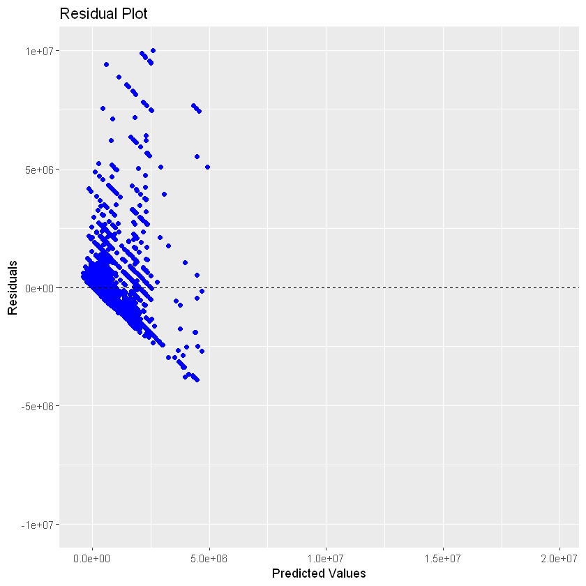

```r
ggplot(pred_df, aes(predicted, residuals)) +
  geom_point(color = 'blue') +
  geom_hline(yintercept = 0, linetype = "dashed") +
  ggtitle("Residual Plot") +
  xlab("Predicted Values") +
  ylab("Residuals") +
  ylim(limits = c(-1e7, 1e7))
```

**Tree based Regression Model**

```r
# Load the necessary libraries
library(tidyverse)
library(rpart)

# Convert the housing_price column to a numeric variable
df$housing_price <- as.numeric(df$housing_price)

# Split the data into training and testing sets
set.seed(123)
train_index <- sample(1:nrow(df), nrow(df) * 0.7)
train_data <- df[train_index, ]
test_data <- df[-train_index, ]

# Train the tree-based regression model
model <- rpart(housing_price ~ Rent + area_property + electricity + electricity_ESCOM + toilet_facility + cooking_fuel + MTLtelephone + source_drinkingWater + disposal_facility + use_bednet, data = train_data)

# Make predictions on the test data
predicted <- predict(model, newdata = test_data)
rmse <- sqrt(mean((predicted - test_data$housing_price)^2))

# Calculate the residuals
residuals <- test_data$housing_price - predicted

rmse
```

1504464.22764948

```
Warning message:
"Computation failed in `stat_smooth()`:
x has insufficient unique values to support 10 knots: reduce k."
```

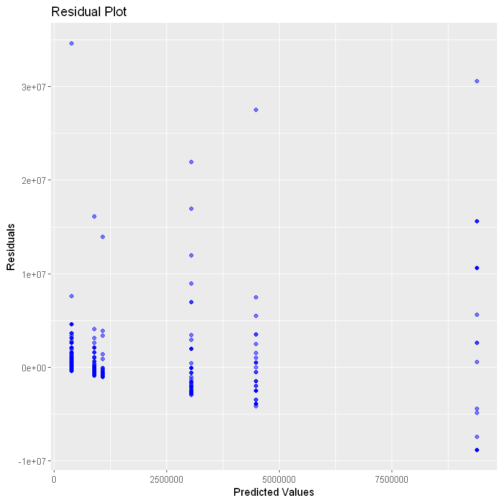

```r
# Create a residual plot
ggplot(data = data.frame(predicted = predicted, residuals = residuals), aes(x = predicted, y = residuals)) +
  geom_point(alpha = 0.5,color = "blue") +
  geom_smooth(se = FALSE, color = "red") +
  labs(title = "Residual Plot", x = "Predicted Values", y = "Residuals")
```

**Random Forest Regression Model**

```r
# Load the necessary libraries
library(caret)
library(randomForest)

# Prepare the data
X <- df[, c("area_property","electricity","Rent" ,"toilet_facility" ,"cooking_fuel" , "MTLtelephone" , "source_drinkingWater" ,"disposal_facility" ,"use_bednet")]
y <- df$housing_price

# Split the data into training and testing sets
set.seed(123)
train_index <- createDataPartition(y, p = 0.7, list = FALSE)
train_data <- X[train_index, ]
train_label <- y[train_index]
test_data <- X[-train_index, ]
test_label <- y[-train_index]

# Perform Random Forest regression
model <- randomForest(x = train_data, y = train_label, ntree = 500, mtry = 2)

# Make predictions on the test data
predicted <- predict(model, test_data)

# Calculate RMSE
rmse <- sqrt(mean((test_label - predicted)^2))

# Print the RMSE
print(paste0("RMSE: ", rmse))
```

```
[1] "RMSE: 1439510.55589611"
```

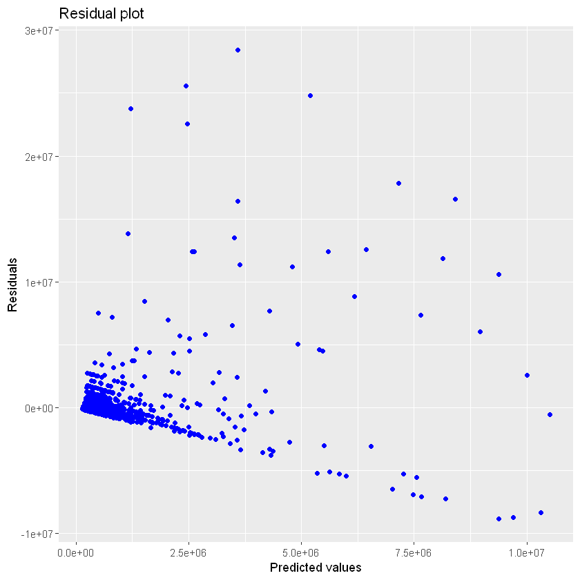

```r
# Load the necessary libraries
library(ggplot2)

# Create a data frame with predicted and residual values
pred_df <- data.frame(predicted = predicted, residual = test_label - predicted)

# Create a residual plot
ggplot(pred_df, aes(x = predicted, y = residual)) +
  geom_point(color = "blue") +
  xlab("Predicted values") +
  ylab("Residuals") +
  ggtitle("Residual plot")
```

```r
# Load the necessary libraries
library(tidyverse)
library(glmnet)

# Load the data into R (replace "data.csv" with the actual filename and path of your data)

# Convert data to matrix format
x <- as.matrix(df[, c("area_property","electricity" ,"toilet_facility" ,"Rent", "cooking_fuel" , "MTLtelephone" , "source_drinkingWater" ,"disposal_facility" ,"use_bednet")]) # Replace with actual predictor names
y <- as.matrix(df$housing_price) # Replace with actual dependent variable name

# Perform Ridge regression
lambda <- 0.1 # Choose the appropriate value of lambda
ridge_model <- glmnet(x, y, alpha = 0, lambda = lambda)

# Calculate RMSE
rmse <- sqrt(mean((predicted - df$housing_price)^2))
print(paste0("RMSE: ", rmse))
```

```
[1] "RMSE: 1838892.03747198"
```

1253958.39504087

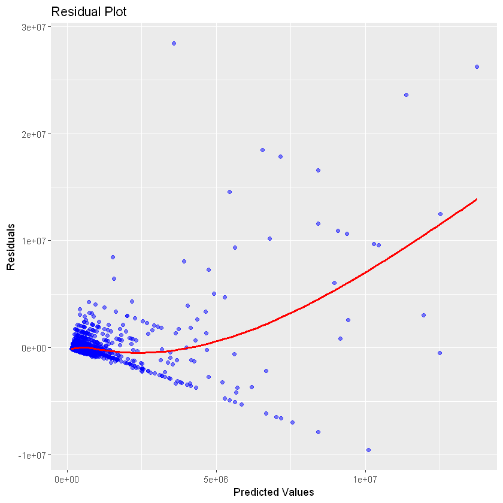

```r
library(gbm)

# Convert the species column to a factor
# df$housing_price <- as.factor(df$housing_price)

# Split the data into training and testing sets
set.seed(123)
train_index <- sample(1:nrow(df), nrow(df) * 0.7)
train_data <- df[train_index, ]
test_data <- df[-train_index, ]

# Train the gradient boosting model
gbm_model <- gbm(housing_price ~ Rent + area_property + electricity + electricity_ESCOM + toilet_facility + cooking_fuel + MTLtelephone + source_drinkingWater + disposal_facility + use_bednet, data = train_data, n.trees = 100, interaction.depth = 2,distribution = "gaussian")

# Make predictions on the test data
predicted <- predict(gbm_model, newdata = test_data, n.trees = 100, type = "response")

#Evaluate the model using accuracy
# accuracy <- sum(predictions == test_data$housing_price) / nrow(test_data)
# print(paste0("Accuracy: ", accuracy))


predicted <- predict(model, newdata = test_data)
rmse <- sqrt(mean((predicted - test_data$housing_price)^2))

# Calculate the residuals
residuals <- test_data$housing_price - predicted

# Create a residual plot
ggplot(data = data.frame(predicted = predicted, residuals = residuals), aes(x = predicted, y = residuals)) +
  geom_point(alpha = 0.5,color = "blue") +
  geom_smooth(se = FALSE, color = "red") +
  labs(title = "Residual Plot", x = "Predicted Values", y = "Residuals")

rmse
```

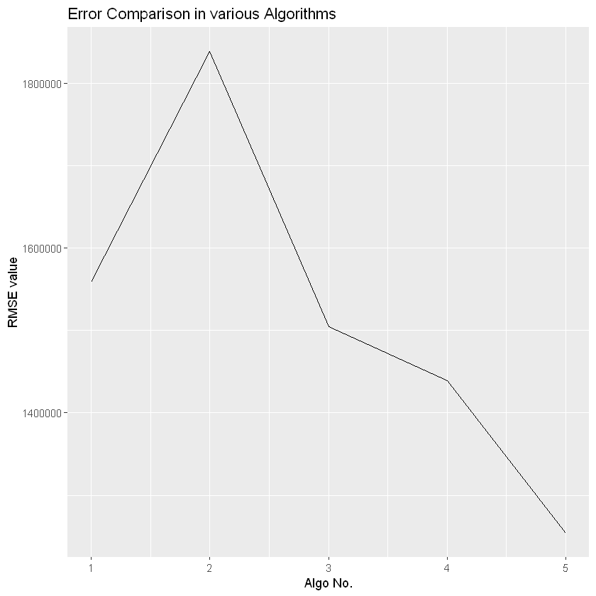

```r
# Load ggplot2 package
library(ggplot2)


x <- c(1, 2, 3, 4, 5)
y <- c(1558824, 1838892, 1504464, 1439510, 1253958)
data <- data.frame(x, y)

# Create plot
ggplot(data, aes(x, y)) +
  geom_line() +
  labs(title = "Error Comparison in various Algorithms", x = "Algo No.", y = "RMSE value")
```